# Ch9 Price Discrimination

Jing Fang

# Ch9 Price Discrimination

- Most markets are not perfectly competitive, and firms have some discretion over their pricing policies.
- In order to maximize profits, these firms may use **nonuniform pricing**: charging customers different prices for the same product or charging a single customer a price that varies depending on how many units the customer buys.

# Ch9 Price Discrimination

- This chapter examines three main questions:
  - What are the common types of nonuniform pricing?
  - What are the necessary conditions for price discrimination to occur?
  - What are the welfare effects of price discrimination?

# Nonuniform Pricing

# Nonuniform Pricing

- In the models of competition, oligopoly, and monopoly discussed so far, the price per unit is the same for all customers.
- Many firms, however, set nonuniform prices.
- See Example 9.1

# Nonuniform Pricing

- This chapter deals with some simple types of price discrimination while Chapter 10 examines more complicated ones, such as:
  1. Two-Part Tariff
  2. Quantity Discount
  3. Tie-in Sale
  4. Quality Discrimination
- Not every seller who charges a nonuniform price is price discriminating.

# Incentive and Conditions for Price Discrimination

# Incentive and Conditions for Price Discrimination

- A firm price discriminates to increase its profit; however, a firm can price discriminate only under certain conditions.

# Profit Motive for Price Discrimination

- Price discrimination is profitable because consumers who value the good the most pay more than if prices were uniform.
- Its MR is the sum of two effects.
- The first is the increase in revenue from selling one more unit.
- The second is the decrease in revenue on all existing output.
- All methods of price discrimination can be viewed as attempts to minimize this second effect on MR from expanding sales.

# Conditions for Price Discrimination

- Even though all firms would like to price discriminate, many are not able to do so three conditions are needed for successful price discrimination.
  1. A firm must have some market power.
  2. The firm must know or be able to infer consumers’ willingness to pay for each unit, and this willingness to pay must vary across consumers or units.
  3. A firm must be able to prevent or limit resales by customers who pay the lower price to those who pay the higher price.

# Resales

- If a firm charges nonuniform prices, consumers who buy at a relatively low price may resell to those facing a relatively high price and thereby render useless the attempt to charge different prices.
- There are at least seven reasons why reselling the good may be difficult or impossible for consumers.

# Resales

- **Services**. Most services cannot be resold. See Example 9.2
- **Warranties**. A manufacturer can void a warranty if a product is resold.
- **Adulteration**. A manufacturer can adulterate a product to make it unfit for other uses.

# Resales

- **Transaction Cost**. If consumers incur any large transaction costs to resell the product, resale are less likely.
- Two important examples of transaction costs are tariffs (a government tax on imported goods) and transportation costs.
- Laws sometimes allow a company to charge more for its product in one country than in another by preventing others from shipping the good from the low-cost country to the other. See Example 9.3

# Resales

- **Contractual Remedies**. A firm may contractually forbid resale as part of its terms of sale.
- **Vertical Integration**. See Example 9.4
- **Government Intervention**. The government can enact laws that allow firms in a competitive industry to act collectively to prevent resale.

# Types of Price Discrimination

# Types of Price Discrimination

- There are many methods for charging nonuniform price.
- We first study first-degree price discrimination, consumers are left with no consumer surplus.
- Then we study third-degree price discrimination, in which each group of consumers faces its own price per unit.
- Chapter 10 examines second-degree discrimination, in which the price per unit depends on the number of units purchased.

# Perfect Price Discrimination

- The purpose behind all methods of price discrimination is to capture as much consumer surplus as possible.
- Suppose that each consumer wants one unit of a product, but consumers are willing to pay a different amount for it, so that the demand curve slopes downward.
- The perfectly discriminating monopoly sells more than the nondiscriminating monopoly because it makes an incremental profit on each additional sale.

# Perfect Price Discrimination

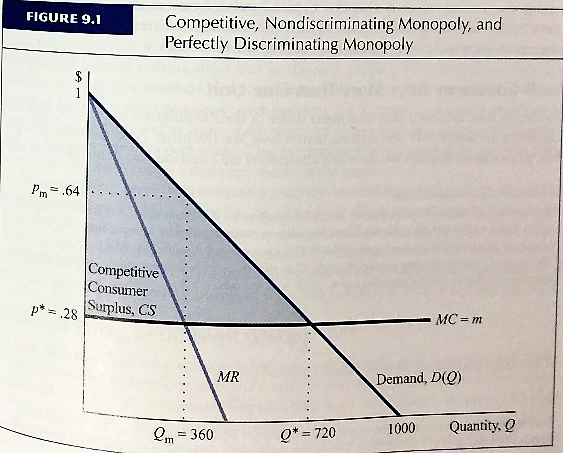

# Each Consumer Buys More Than One Unit

- Now consider how perfect price discrimination works when consumers are identical but demand more units as price falls.
- A perfectly discriminating monopoly charges a different price for each unit of the product that is sold and thus, by charging quantity-dependent prices, extracts all the CS from each customer.
- An alternative and equivalent method of perfect price discrimination would be to charge an optimal two-part tariff. See Example 9.5

# Each Consumer Buys More Than One Unit

- If each consumer has a downward-sloping demand curve but consumers differ, the monopoly charges each consumer m per unit consumed but charges each one a different lump-sum fee in order to extract all of the consumer surplus.
- Because perfect price discrimination requires detailed knowledge about individual buyers, it is more likely to occur when one-on-one bargaining occurs.

# Different Prices to Different Groups

- A firm that does not have enough information to identify each customer and determine what each one is willing to pay is unable to practice first-degree price discrimination and extract all CS.
- The firm may have, however, enough information to imperfectly price discriminate.

# Different Prices to Different Groups

- Suppose:
  - A firm can determine whether a particular customer belongs to one group rather than another where the demand elasticities for the aggregate demand curves of the two group differ.
  - It is possible to prevent resale between the two groups
  - The firm knows the aggregate demand curve of each group.

# Different Prices to Different Groups

- It is profitable to set different prices for the two groups.
- The monopoly is practicing third-degree price discrimination: It charges consumers in different groups different unit prices.

# Different Prices to Different Groups

- If the monopoly has a constant MC and AC, m, its profit, $p_i$, is:
  $$\pi=[p_1(Q_1)-m]Q_1+[p_2(Q_2)-m]Q_2$$
- The monopoly maximizes its total profit by maximizing its profits from sales to each of the groups separately.
- $$\begin{matrix}
  MR_1 & = & p_1(1+\frac{1}{\varepsilon_1})=m \\
  MR_2 & = & p_2(1+\frac{1}{\varepsilon_2})=m
  \end{matrix}$$

# Different Prices to Different Groups

- Because the MC, m, is the same in both equations, it follows that the profit-maximizing monopoly equates MR across the two markets: $MR_1=MR_2$.
- The pricing decision of the discriminating monopoly is illustrated in Figure 9.2.

# Different Prices to Different Groups

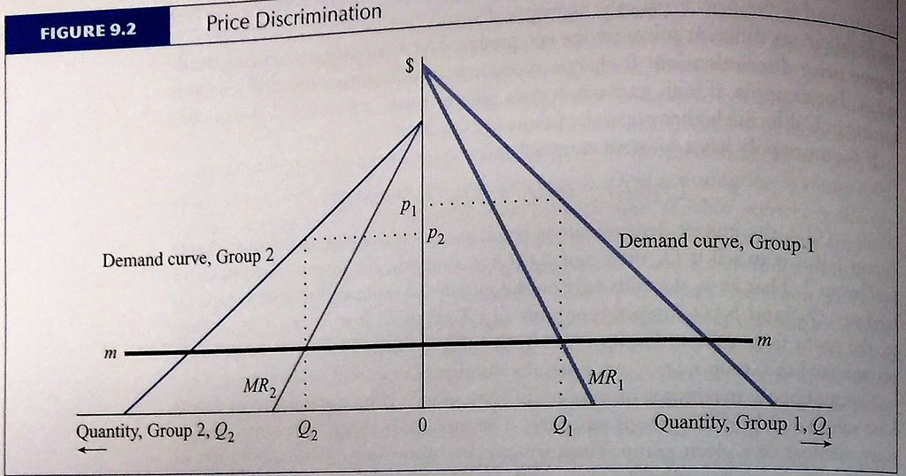

# Different Prices to Different Groups

- We can rewrite as:
  $$\begin{matrix}
  \frac{p_1-m}{p_1} & = & -\frac{1}{\varepsilon_1} \\
  \frac{p_2-m}{p_2} & = & -\frac{1}{\varepsilon_2}
  \end{matrix}$$
- They can be combined to show that the price ratio to the two groups depends on their relative elasticities.

# Different Prices to Different Groups

- Still another method of price discrimination is to make the price that the consumer pays depend on whether the consumer turns in a previous version of the product, as well as the identity of the manufacturer of that previous version.

# Other Methods of Third-Degree Price Discrimination

- Firms can practice third-degree price discrimination in other, subtle ways.
- For example, in many markets some consumers are better informed than others about prices.
- One way a firm can charge different prices to consumers is to set a high list price.
- The firm charges the list price unless a customer complains that it exceeds the price of the product at other stores.
- In the event of a complaint, the store matches the lower price.

# Other Methods of Third-Degree Price Discrimination

- Another example of third-degree price discrimination involves exploiting differences in the value customers place on time.
- High-wage, high-income people typically value their time more than low-wage, low-income people.
- One clever way to price discriminate between these two groups is to make a special Offer that requires consumers to spend time to take advantage of the offer.

# Other Methods of Third-Degree Price Discrimination

- A related method of price discrimination is to exploit differences in the willingness of consumers to wait to consume a new product.

# Welfare Effects of Price Discrimination

# Welfare Effects of Price Discrimination

- There is no ambiguity about the welfare effects of perfect price discrimination.
- Output is at the efficient, competitive level, but consumers are poorer than they are under competition; therefore, perfect price discrimination does not distort efficiency but does affect the distribution of income.

# Welfare Effects of Price Discrimination

- The welfare effects of third-degree discrimination are more difficult to analyze.
- We do know that, as with first-degree discrimination, consumers wind up with less surplus than under competition.
- Moreover, we know that third-degree price discrimination prices exceed marginal costs, so they are not as efficient as perfect competition or perfect price discrimination.
- Third-degree price discrimination, however, may be better or worse than nondiscriminating monopoly pricing from an efficiency viewpoint, depending on the shapes of the demand and cost curves.

# Welfare Effects of Price Discrimination

- Three sources of inefficiency are present in third-degree discrimination.
- The first is the usual one associated with monopoly: Price exceeds MC, which results in an output restriction and hence an output inefficiency.
- The second is a consumption inefficiency.
- A third source of inefficiency is that consumers may have to expend resources that do not benefit the firm to obtain a low price.

# Welfare Effects of Price Discrimination

- Welfare may be higher with third-degree price discrimination than with a nondiscriminating monopoly if output is higher with discrimination. See Example 9.6
- The antitrust laws ban certain types of price discrimination.